# Ford GoBike Dataset Exploration

# Visualization

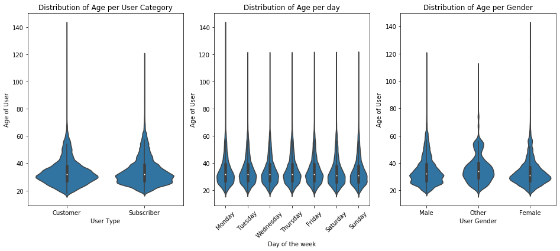

```python
#subplots showing violinplots for distribution comparison with respect to user type,their genders,their ages,ride durations
#and days of rides
fig, ax = plt.subplots(ncols = 3, figsize = [16,6])

sb.violinplot(data = ford_copy, x = 'user_type', y = 'member_approximate_age',ax = ax[0],color = color)
ax[0].set_xlabel('User Type')
ax[0].set_title('Distribution of Age per User Category')
ax[0].set_ylabel('Age of User')

sb.violinplot(data = ford_copy, x = 'day', y = 'member_approximate_age',ax = ax[1],color = color)
ax[1].set_xlabel('Day of the week')
ax[1].set_title('Distribution of Age per day')
ax[1].set_ylabel('Age of User')
ax[1].set_xticklabels(['Monday','Tuesday','Wednesday','Thursday','Friday','Saturday','Sunday'],rotation = 45)

sb.violinplot(data = ford_copy, x = 'member_gender', y = 'member_approximate_age',color = color)
ax[2].set_xlabel('User Gender')
ax[2].set_title('Distribution of Age per Gender')
ax[2].set_ylabel('Age of User');
```

# Observations

From the plots,it is obvious that the age range of users with respect to their types,genders and days of rides are between 20 and 60 years old

# Question

- What is the relationship between the Age of Users and their Ride Durations?

# Visualization

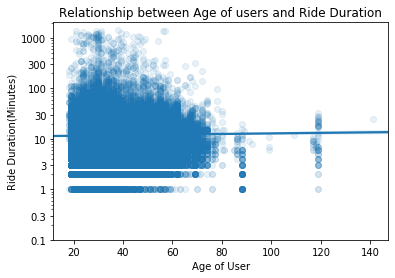

```python
#regression plot sowing relationship between ages and ride durations
sb.regplot(data = ford_copy,x = 'member_approximate_age',y = 'trip_duration_in_minutes',scatter_kws={'alpha':0.1})
ytick = [0.1,0.3,1,3,10,30,100,300,1000]
plt.title('Relationship between Age of users and Ride Duration')
plt.xlabel('Age of User')
plt.ylabel('Ride Duration(Minutes)')
plt.yscale('log')
plt.yticks(ytick,ytick);
```

# Observations

There is a very weak positive relationship between the age of users and ride duration

# Question

- What is the frequency comparison with respect to user genders,user types and days?

```python
#pivot/cross tabulation of user types,their genders and frequency
to_group1 = ford_copy.groupby(['user_type','member_gender']).size().reset_index()
to_group1 = to_group1.rename(columns ={0:'count'})
to_group1 = to_group1.pivot(index = 'user_type',columns = 'member_gender',values = 'count')
to_group1
```

| member_gender user_type | Female | Male | Other |
| --- | --- | --- | --- |
| Customer | 4623 | 11493 | 450 |
| Subscriber | 36182 | 119007 | 3197 |

```python
#pivot/cross tabulation of days,genders and frequency
to_group2 = ford_copy.groupby(['day','member_gender']).size().reset_index()
to_group2 = to_group2.rename(columns ={0:'count'})
to_group2 = to_group2.pivot(index = 'day',columns = 'member_gender',values = 'count')
to_group2
```

| member_gender day | Female | Male | Other |
| --- | --- | --- | --- |
| Monday | 5300 | 16991 | 466 |
| Tuesday | 6522 | 21304 | 538 |
| Wednesday | 6645 | 22039 | 611 |
| Thursday | 7917 | 24445 | 688 |
| Friday | 4814 | 16562 | 460 |
| Saturday | 5433 | 16939 | 517 |
| Sunday | 4174 | 12220 | 367 |

```python
#pivot/cross tabulation of days,user types and frequency
to_group3 = ford_copy.groupby(['day','user_type']).size().reset_index()
to_group3 = to_group3.rename(columns ={0:'count'})
to_group3 = to_group3.pivot(index = 'day',columns = 'user_type',values = 'count')
to_group3
```

| user_type day | Customer | Subscriber |
| --- | --- | --- |
| Monday | 2219 | 20538 |
| Tuesday | 2116 | 26248 |
| Wednesday | 2490 | 26805 |
| Thursday | 2774 | 30276 |
| Friday | 2069 | 19767 |
| Saturday | 2817 | 20072 |
| Sunday | 2081 | 14680 |

# Visualization

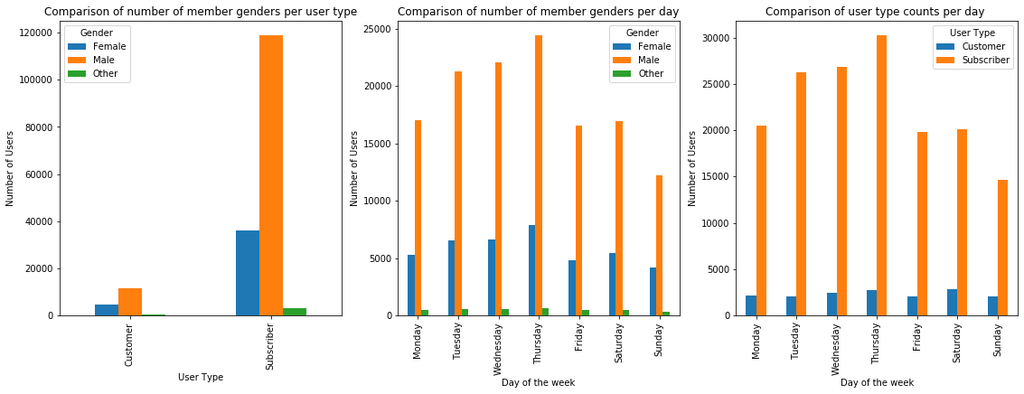

```python
#subplots with grouped bar charts showing comparisons with respect to user genders,user types and days
fig, ax = plt.subplots(ncols = 3, figsize = [19,6])
to_group1.plot(kind = 'bar',ax = ax[0])

ax[0].set_xlabel('User Type')
ax[0].set_title('Comparison of number of member genders per user type')
ax[0].set_ylabel('Number of Users')
ax[0].legend(title = 'Gender',loc = 'upper left')

to_group2.plot(kind = 'bar',ax = ax[1])

ax[1].set_xlabel('Day of the week')
ax[1].set_title('Comparison of number of member genders per day')
ax[1].set_ylabel('Number of Users')
ax[1].legend(title = 'Gender',loc = 'upper right')

to_group3.plot(kind = 'bar',ax = ax[2])

ax[2].set_xlabel('Day of the week')
ax[2].set_title('Comparison of user type counts per day ')
ax[2].set_ylabel('Number of Users')
ax[2].legend(title = 'User Type',loc = 'upper right');
```

# Observations

- Plot 1

Most of the users in the bike sharing system are male subscribers

- Plot 2

On thursdays which is the days of most rides had more males than other genders

- Plot 3

On thursdays which is the days of most rides had more subscribers

### Talk about some of the relationships you observed in this part of the investigation. How did the feature(s) of interest vary with other features in the dataset?

> With respect to other features also,I noticed that the user type still had subscribers standing out more in terms of gender,age,ride duration etc. The domination of cycling by males also shows in the sense that with respect to other features (like being subscribers) they still stand out as they have a high contribution to the engagement to the bike sharing system .

### Did you observe any interesting relationships between the other features (not the main feature(s) of interest)?

> There is an obvious relationship between the age range for each member gender and the age range of users per day of the week.

# Question

- Is there a relationship between ages and ride durations of customers and subscribers?

# Visualization

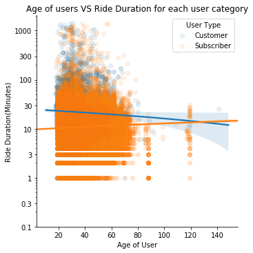

```python
#plotting relationships between age of users and their ride durations with respect to the user type
ytick = [0.1,0.3,1,3,10,30,100,300,1000]
sb.lmplot(data = ford_copy,x = 'member_approximate_age',y = 'trip_duration_in_minutes',hue = 'user_type',scatter_kws={'alpha':0.1},legend = False)
plt.title('Age of users VS Ride Duration for each user category')
plt.xlabel('Age of User')
plt.ylabel('Ride Duration(Minutes)')
plt.yscale('log')
plt.legend(title = 'User Type')
plt.yticks(ytick,ytick);
```

# Observations

1. There is a weak negative relationship between age and ride duration of customers i.e the higher their age,the lower their ride durations
2. There is a weak positive relationship between age and ride duration of subscribers i.e the higher their age,the higher their ride durations

# Question

- Is there a relationship between ages and ride durations of each user gender?

# Visualization

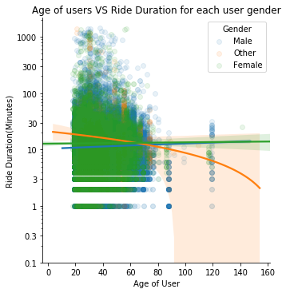

```python
#plotting relationships between age of users and their ride durations with respect to their gender
sb.lmplot(data = ford_copy,x = 'member_approximate_age',y = 'trip_duration_in_minutes',hue = 'member_gender',scatter_kws={'alpha':0.1},legend = False)
ytick = [0.1,0.3,1,3,10,30,100,300,1000]
plt.title('Age of users VS Ride Duration for each user gender')
plt.xlabel('Age of User')
plt.ylabel('Ride Duration(Minutes)')
plt.legend(title = 'Gender')
plt.yscale('log')
plt.yticks(ytick,ytick);
```

# Observations

1. There is a weak positive linear relationship between age and ride duration of Male users i.e the higher their age,the higher their ride durations
2. There is a weak positive linear relationship between age and ride duration of Female users i.e the higher their age,the higher their ride durations
3. There is a weak negative curved relationship between age and ride duration of Other users i.e the higher their age,the lower their ride durations

# Question

- What is the ride duration comparison per user type for each day of the week?

# Visualization

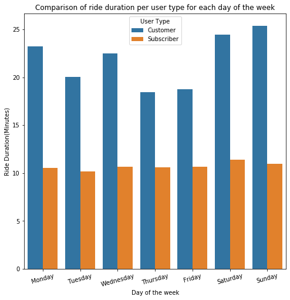

```python
#grouped bar chart for comparison of ride duration per user type for each day of the week
plt.figure(figsize = (8,8))
sb.barplot(data = ford_copy,x = 'day',y = 'trip_duration_in_minutes',hue = 'user_type',ci = None)
plt.legend(title = 'User Type',loc = 'upper center')
plt.xticks(rotation = 15)
plt.title('Comparison of ride duration per user type for each day of the week')
plt.xlabel('Day of the week')
plt.ylabel('Ride Duration(Minutes)');
```

# Observations

From the plot,more users take long on the road mostly on weekends(customers and subscribers)

# Question

- What is ride duration comparison per user gender for each user type?

# Visualization

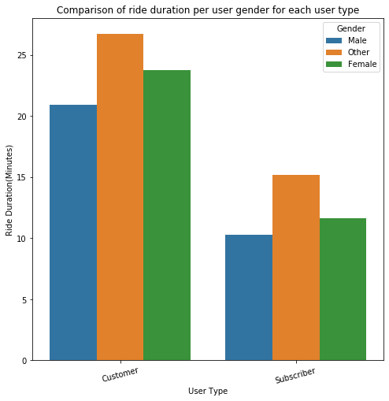

```python
#grouped bar chart for Comparison of ride duration per user gender for each user type
plt.figure(figsize = (8,8))
sb.barplot(data = ford_copy,x = 'user_type',y = 'trip_duration_in_minutes',hue = 'member_gender',ci = None)
plt.legend(loc = 2)
plt.xticks(rotation = 15)
plt.title('Comparison of ride duration per user gender for each user type')
plt.xlabel('User Type')
plt.ylabel('Ride Duration(Minutes)')
plt.legend(title = 'Gender',loc = 1);
```

# Observations

Most users that ride the bikes for longer durations are mostly customers no matter the gender

# Question

- Are there any relationships in how ages are distributed with respect to gender,user type and days of the week?

# Visualization

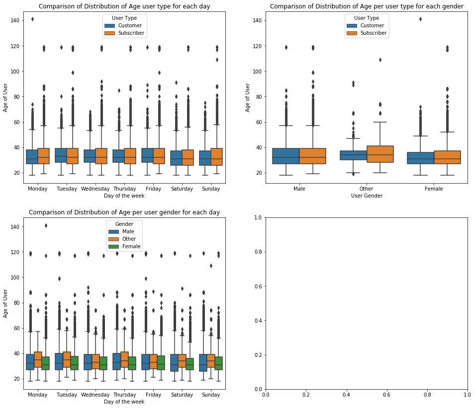

```python
#grouped box plot
fig, ax = plt.subplots(nrows = 2,ncols = 2, figsize = [16,14])
sb.boxplot(data = ford_copy,x = 'day',y = 'member_approximate_age',hue = 'user_type',ax = ax[0,0],dodge = True)

ax[0,0].set_xlabel('Day of the week')
ax[0,0].set_title('Comparison of Distribution of Age user type for each day')
ax[0,0].set_ylabel('Age of User')
ax[0,0].legend(title = 'User Type',loc = 'upper center')

sb.boxplot(data = ford_copy,x = 'member_gender',y = 'member_approximate_age',hue = 'user_type',ax = ax[0,1])

ax[0,1].set_xlabel('User Gender')
ax[0,1].set_title('Comparison of Distribution of Age per user type for each gender')
ax[0,1].set_ylabel('Age of User')
ax[0,1].legend(title = 'User Type',loc = 'upper center')

sb.boxplot(data = ford_copy,x = 'day',y = 'member_approximate_age',hue = 'member_gender',ax = ax[1,0])

ax[1,0].set_xlabel('Day of the week')
ax[1,0].set_title('Comparison of Distribution of Age per user gender for each day')
ax[1,0].set_ylabel('Age of User')
ax[1,0].legend(title = 'Gender',loc = 'upper center');
```

# Observations

- Plot 1

- Plot 2

The distribution of male customers and male subscribers ages were the same

- Plot 3

There is a very high relationship in how the ages of males were distributed on weekdays

### Were there any interesting or surprising interactions between features?

> There were opposite relationships between the ages and ride durations of each user type which I didn't expect because I assumed they would both have negative relationships because for an increase in age,there is supposed to be a decrease in ride duration since older people don't go on long distance journey especially on bikes.

## Conclusions

> The bike sharing system has its advantages and disadvanges but one of its advantages is making transit convenient and flexible. Even if the users of the bikes mostly make their orders on weekdays,mainly Thursdays.With respect to trip duration.This contributes to the engagement of users in using the system for long duration journeys on weekends and shorter ones on weekdays because the weekend journeys are usually occasional while the one on weekdays are more repititive. This benefits is one the reasons subscribers stand out more.

# References

- [Trip Advisor](https://www.tripadvisor.com/Attraction_Review-g60713-d12951811-Reviews-Ford_GoBike-San_Francisco_California.html)
- [Ford Website](https://www.ford.com/)
- [Tom's Blog](https://www.tomsofmaine.com/good-matters/thinking-sustainably/benefits-bike-sharing-you-and-planet)